# Project_Full_Code_Notebook_EasyVisa_RDMET

### Hyperparameter Tuning - XGBoost

```python
# 1. Define a pipeline that chains SMOTE and Random Forest together
xgb_pipeline = ImbPipeline([
    ('smote', SMOTE(random_state=1)),
    ('xgb', XGBClassifier(random_state=1, eval_metric="logloss"))
])

parameters = {
    "xgb__n_estimators": np.arange(50,110,25),
    "xgb__scale_pos_weight": [1,2,5],
    "xgb__subsample": [0.9, 1],
    "xgb__learning_rate": [0.01,0.1,0.05],
    "xgb__gamma": [1,3]
}

grid_obj = GridSearchCV(xgb_pipeline, parameters, scoring=acc_scorer, cv=5, n_jobs=-1)
grid_obj.fit(X_train, y_train)

# 4. Extract the ultimate tuned model
# This automatically includes the SMOTE step for final training
xgb_best_model = grid_obj.best_estimator_
```

```python
xgb_best_model.fit(X_train, y_train)
```

```
Pipeline(steps=[('smote', SMOTE(random_state=1)),
                ('xgb',
                 XGBClassifier(base_score=None, booster=None, callbacks=None,
                               colsample_bylevel=None, colsample_bynode=None,
                               colsample_bytree=None, device=None,
                               early_stopping_rounds=None,
                               enable_categorical=False, eval_metric='logloss',
                               feature_types=None, feature_weights=None,
                               gamma=1, grow_policy=None, importance_type=None,
                               interaction_constraints=None, learning_rate=0.1,
                               max_bin=None, max_cat_threshold=None,
                               max_cat_to_onehot=None, max_delta_step=None,
                               max_depth=None, max_leaves=None,
                               min_child_weight=None, missing=nan,
                               monotone_constraints=None, multi_strategy=None,
                               n_estimators=np.int64(75), n_jobs=None,
                               num_parallel_tree=None, ...))])
```

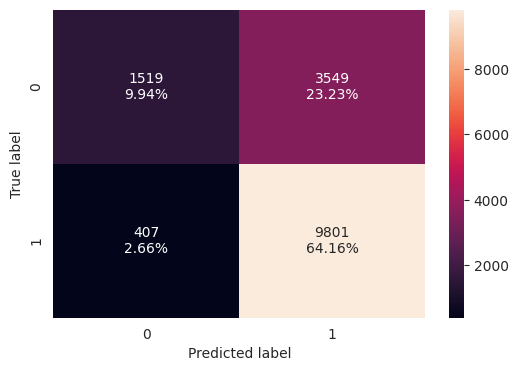

```python
confusion_matrix_sklearn(xgb_best_model, X_train, y_train)
```

```python
xgb_tuned_model_train_perf = model_performance_classification_sklearn(xgb_best_model, X_train, y_train)
xgb_tuned_model_train_perf
```

|  | Accuracy | Recall | Precision | F1 |
| --- | --- | --- | --- | --- |
| 0 | 0.74 | 0.96 | 0.73 | 0.83 |

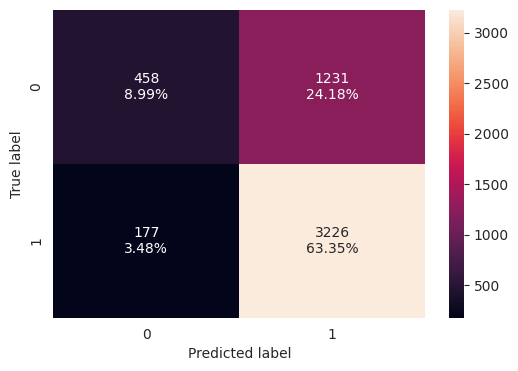

```python
confusion_matrix_sklearn(xgb_best_model, X_val, y_val)
```

```python
xgb_tuned_model_val_perf = model_performance_classification_sklearn(xgb_best_model, X_val, y_val)
xgb_tuned_model_val_perf
```

|  | Accuracy | Recall | Precision | F1 |
| --- | --- | --- | --- | --- |
| 0 | 0.72 | 0.95 | 0.72 | 0.82 |

# **Model Comparison and Final Model Selection**

```python
# training performance comparison

models_train_comp_df = pd.concat(
    [
        bag_tuned_model_train_perf.T,
        rf_tuned_model_train_perf.T,
        ada_tuned_model_train_perf.T,
        grad_tuned_model_train_perf.T,
        xgb_tuned_model_train_perf.T,
    ],
    axis=1,
)
models_train_comp_df.columns = [
    "Tuned Bagging Model",
    "Tuned Random Forest",
    "Tuned Adaboost Classifier",
    "Tuned Gradient Boost Classifier",
    "XGBoost Classifier Tuned",
]
print("Training performance comparison:")
models_train_comp_df
```

```
Training performance comparison:
```

|  | Tuned Bagging Model | Tuned Random Forest | Tuned Adaboost Classifier | Tuned Gradient Boost Classifier | XGBoost Classifier Tuned |
| --- | --- | --- | --- | --- | --- |
| Accuracy | 0.72 | 0.78 | 0.72 | 0.72 | 0.74 |
| Recall | 0.88 | 0.91 | 0.90 | 0.90 | 0.96 |
| Precision | 0.75 | 0.79 | 0.74 | 0.74 | 0.73 |
| F1 | 0.81 | 0.85 | 0.81 | 0.81 | 0.83 |

```python
# validation performance comparison

models_val_comp_df = pd.concat(
    [
        bag_tuned_model_val_perf.T,
        rf_tuned_model_val_perf.T,
        ada_tuned_model_val_perf.T,
        grad_tuned_model_val_perf.T,
        xgb_tuned_model_val_perf.T,
    ],
    axis=1,
)
models_train_comp_df.columns = [
    "Tuned Bagging Model",
    "Tuned Random Forest",
    "Tuned Adaboost Classifier",
    "Tuned Gradient Boost Classifier",
    "XGBoost Classifier Tuned",
]
print("Validation performance comparison:")
models_train_comp_df
```

```
Validation performance comparison:
```

[output not shown]

Based on the above criteria using the F1 score, the best model is the tuned Random Forest.

### Model Results on the test set

```python
#fit the tuned random forest model to the test data
final_model = rf_tuned
final_model.fit(X_test, y_test)
```

```
RandomForestClassifier(max_depth=np.int64(10), min_samples_split=5,
                       n_estimators=np.int64(30), oob_score=True,
                       random_state=1)
```

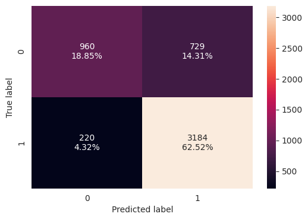

```python
confusion_matrix_sklearn(final_model, X_test, y_test)
```

```python
final_model_test_score = model_performance_classification_sklearn(final_model, X_test, y_test)
final_model_test_score
```

|  | Accuracy | Recall | Precision | F1 |
| --- | --- | --- | --- | --- |
| 0 | 0.81 | 0.94 | 0.81 | 0.87 |

As you can see above, the final model had an F1 Score of 0.87 and an overall accuracy of 0.81.

### Feature Importances of the Final Model

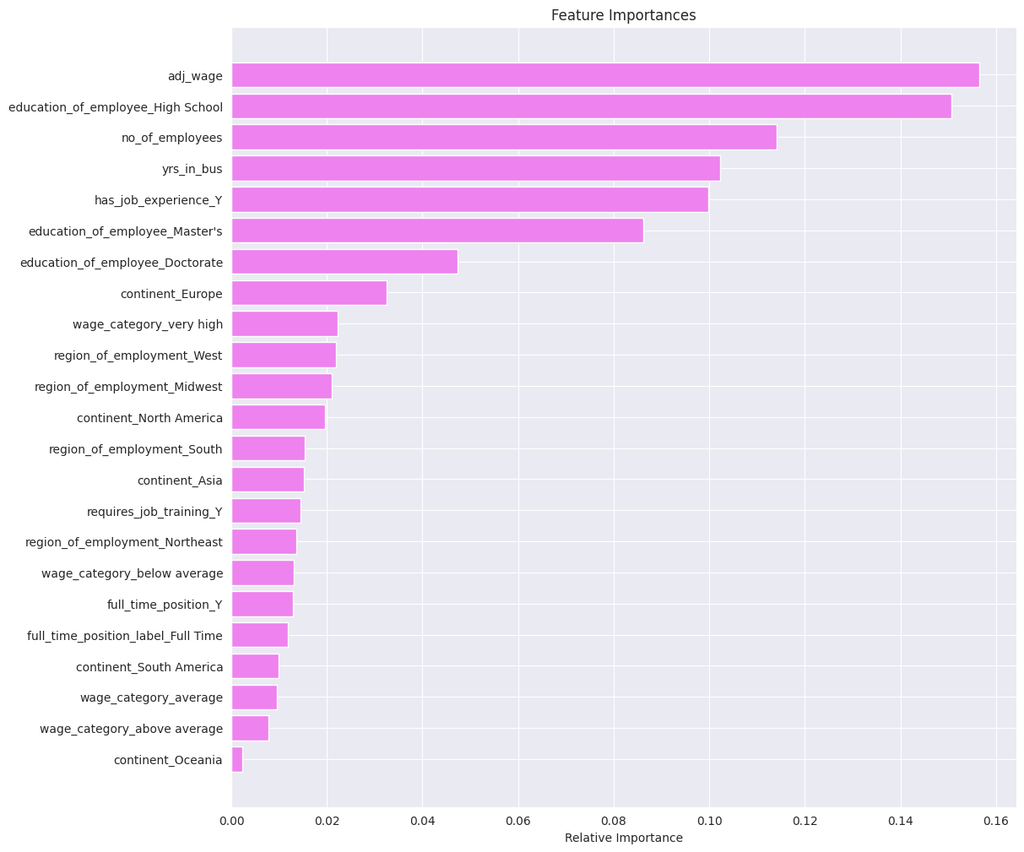

```python
#graph important features of the final model
feature_names = X_train.columns
importances =  final_model.feature_importances_
indices = np.argsort(importances)

plt.figure(figsize=(12, 12))
plt.title("Feature Importances")
plt.barh(range(len(indices)), importances[indices], color="violet", align="center")
plt.yticks(range(len(indices)), [feature_names[i] for i in indices])
plt.xlabel("Relative Importance")
plt.show()
```

From the chart above, the engineered category of adjusted wage (`adj_wage`) was the most significant feature in predicting the result of the model. The second most important feature was high school level of education followed by the number of employees.

# **Actionable Insights and Recommendations**

### **Business Recommendations**

# **Appendix**

Click here to return to the Exploratory Data Analysis (EDA).

```python
#Recreate the copy of precleaned data
viz_data = df.copy()
```

```python
viz_data.info()
```

```
<class 'pandas.core.frame.DataFrame'>
RangeIndex: 25480 entries, 0 to 25479
Data columns (total 12 columns):
 #   Column                 Non-Null Count  Dtype
---  ------                 --------------  -----
 0   case_id                25480 non-null  object
 1   continent              25480 non-null  object
 2   education_of_employee  25480 non-null  object
 3   has_job_experience     25480 non-null  object
 4   requires_job_training  25480 non-null  object
 5   no_of_employees        25480 non-null  int64
 6   yr_of_estab            25480 non-null  int64
 7   region_of_employment   25480 non-null  object
 8   prevailing_wage        25480 non-null  float64
 9   unit_of_wage           25480 non-null  object
 10  full_time_position     25480 non-null  object
 11  case_status            25480 non-null  object
dtypes: float64(1), int64(2), object(9)
memory usage: 2.3+ MB
```

## One Variable Analysis

### Observations on `no_of_employees`

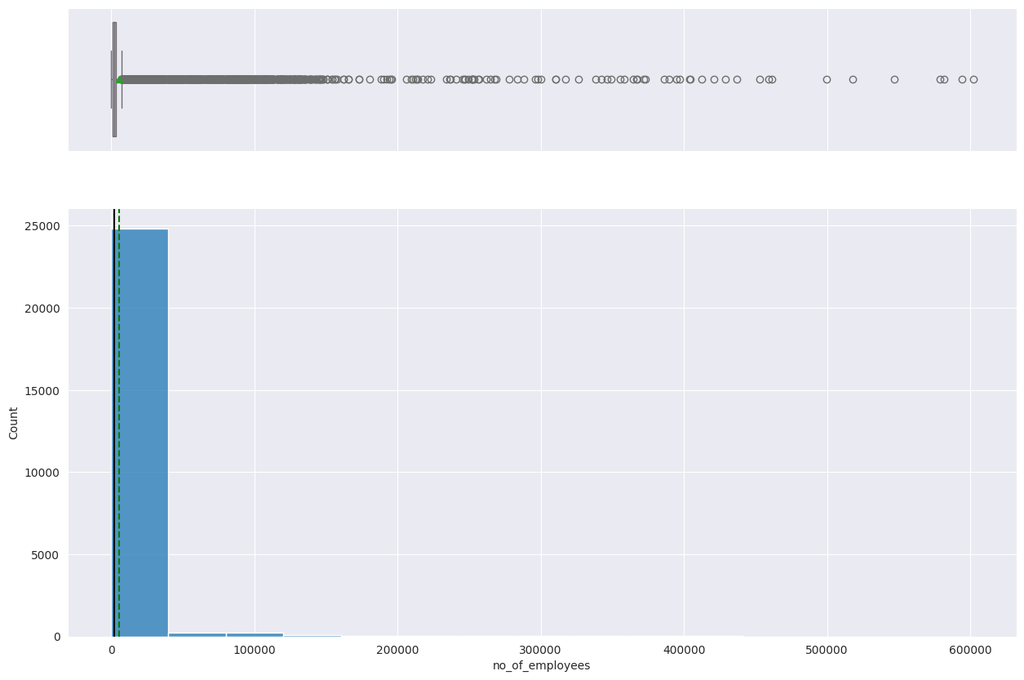

```python
histogram_boxplot(viz_data, 'no_of_employees', bins = 15)
```

- most companies bringing in employees are very small, but some unusually large companies (50000+ employees) are heavily skewing the data to the right

### Observations on `yr_of_estab`

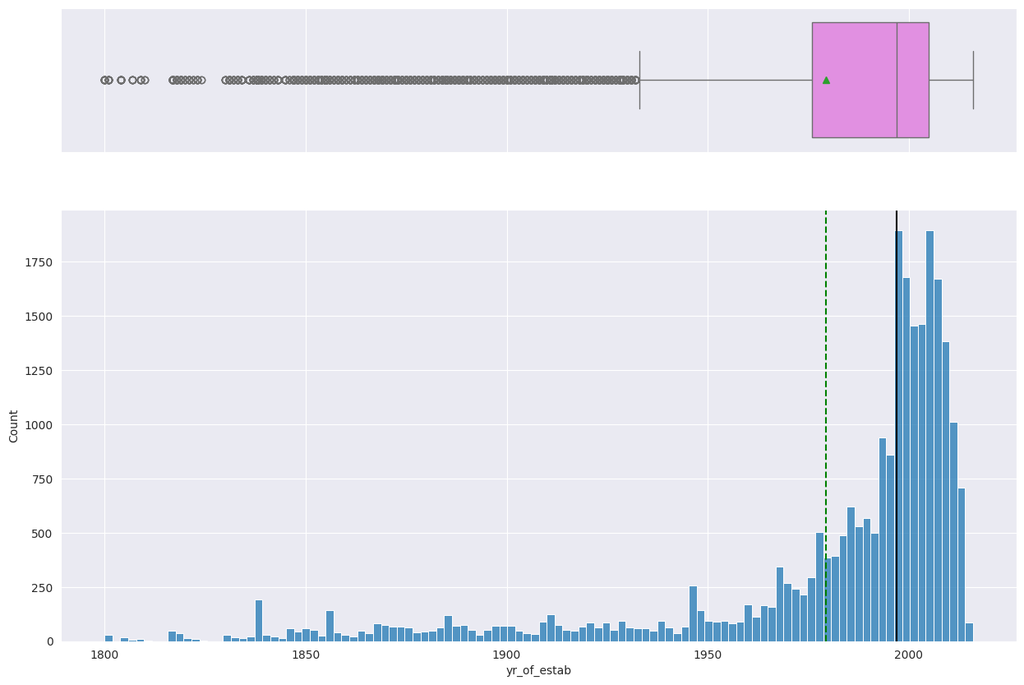

```python
histogram_boxplot(viz_data, 'yr_of_estab')
```

*companies establishment year are heavily left skewed with a majority of companies being founded after 1980.

- some very long established companies (pre-1900) are bringing in employees

### Observations on `prevailing_wage`

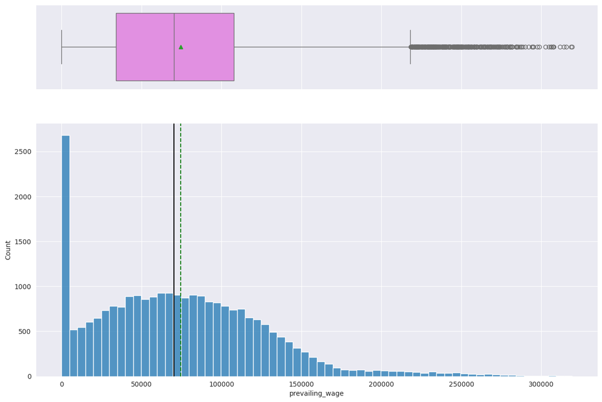

```python
histogram_boxplot(viz_data, 'prevailing_wage')
```

```python
viz_data['prevailing_wage'].describe()
```

|  | prevailing_wage |
| --- | --- |
| count | 25480.00 |
| mean | 74455.81 |
| std | 52815.94 |
| min | 2.14 |
| 25% | 34015.48 |
| 50% | 70308.21 |
| 75% | 107735.51 |
| max | 319210.27 |

**dtype:** float64

- This distribution is truly unusual. It is right skewed but with a very tall bin on the far left
- this causes the mean and median to be relatively close despite the skew
- looking at the data, this distribution is because some companies report hourly wage, while others report weekly, monthly, or yearly.
- feature engineering may be necessary to address this

### Observations on `continent`

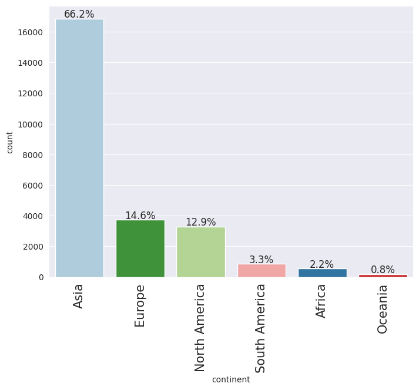

```python
labeled_barplot(viz_data, "continent", perc=True)
```

- the vast majority (66.2%) of the visas were issued to applicants from the Asian continent
- Europe and North America were roughly equivalent in the low teens.
- Only a very small percentage of applications came from South America, Africa, and Oceania. The reasons behind these trends may warrant study. However, based on a quick internet search, Asia, North America, South America, and Oceania applications are similar to the percentage of the world's population from those countries. Europe is over-represented per capita and Africa is under-represented.

***Observations on `Education_of_employee`

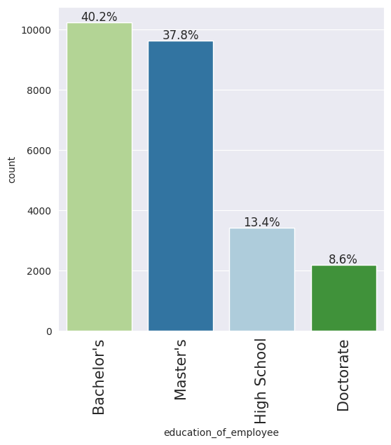

```python
labeled_barplot(viz_data, "education_of_employee", perc=True)
```

- Most applicants (78%) have a college degree or master's.
- Doctoral applicants are relatively high based on per capita degree holders.
- High school degree is the second lowest category.

### Observations on `has_job_experience`

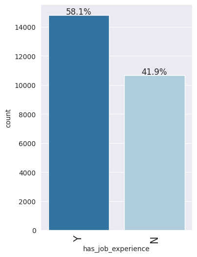

```python
labeled_barplot(viz_data, "has_job_experience", perc=True)
```

- Based on the high number of degree and advanced degree olders, the high proportion of applicants without job experience is surprising.
- A bivariate analysis might be interesting here

### Observations on `requires_job_training`

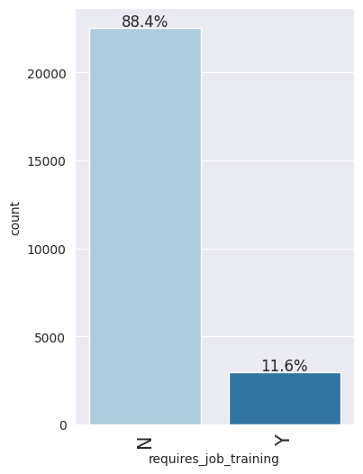

```python
labeled_barplot(viz_data, "requires_job_training", perc=True)
```

- This trend is less surprising, assuming that "No" training aligns with degree holders *A bivariate approach is also needed here

### Observations on `region_of_employment`

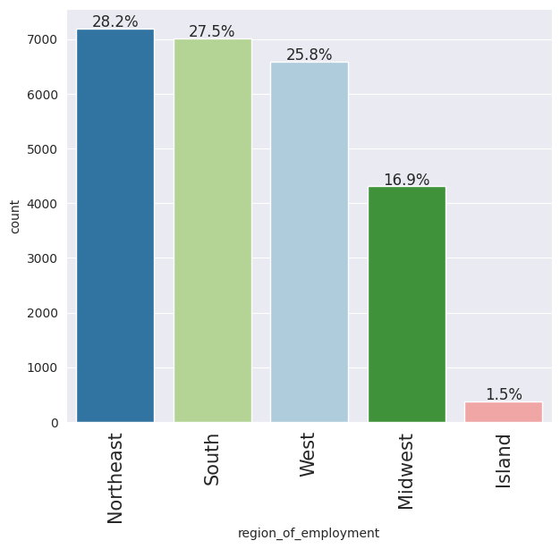

```python
labeled_barplot(viz_data, "region_of_employment", perc=True)
```

- The region of the US in which employment is sought appears to roughly correlate with population density.

### Observations on `unit_of_wage`

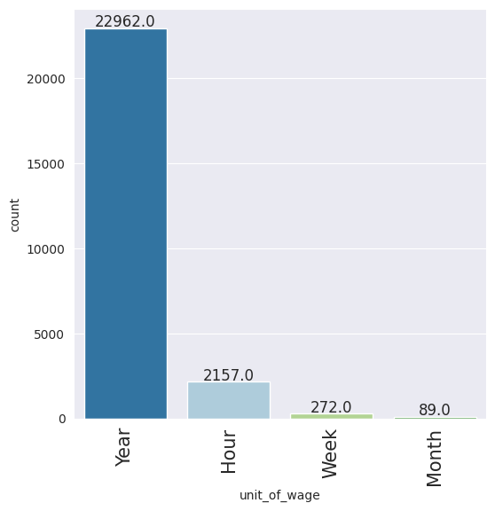

```python
labeled_barplot(viz_data, "unit_of_wage", perc=False)
```

- there appears to be a discrepancy between the unit of wage and the wage amount. This requires a deeper analysis
- most wages reported are yearly ones
- hourly wages are the second most commonly occuring one
- these discrepancies **strongly** suggest the need for feature engineering on the wage category

### Observations on `full_time_position`

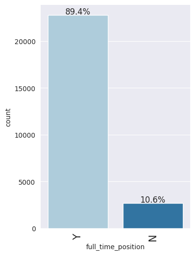

```python
labeled_barplot(viz_data, "full_time_position", perc=True)
```

- The vast majority of visa applications were for full time positions

### Observations on `case_status`

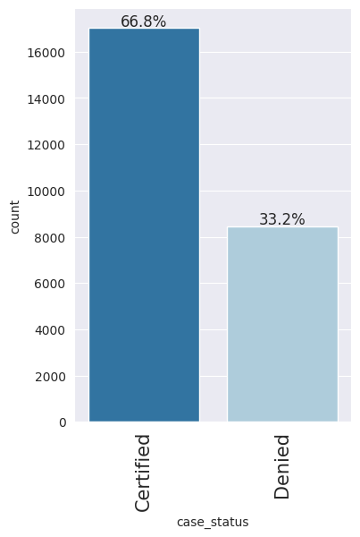

```python
labeled_barplot(viz_data, "case_status", perc=True)
```

- This is the target variable
- roughly 2/3 of the applications were certified
- seeing how this variable correlates with the ones above will be beneficial

## Multivariable Analysis

### Observations on Correlation Matrix

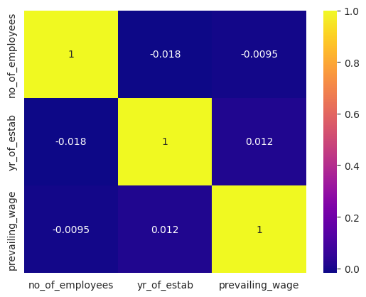

```python
#create a correlation matrix of numeric values

corr_matrix = viz_data.corr(numeric_only = True)

#create a heatmap visualization for the correlation matrix

sns.heatmap(corr_matrix, cmap = "plasma", annot = True)
```

### Categorical data grouped together.

### Observations on `Continent` and `Education_of_employee`

```
education_of_employee  Bachelor's  Doctorate  High School  Master's    All
continent
All                         10234       2192         3420      9634  25480
Asia                         7168        923         2290      6480  16861
Europe                       1299        846          490      1097   3732
North America                1225        258          401      1408   3292
South America                 333         89          137       293    852
Africa                        143         54           66       288    551
Oceania                        66         22           36        68    192
------------------------------------------------------------------------------------------------------------------------
```

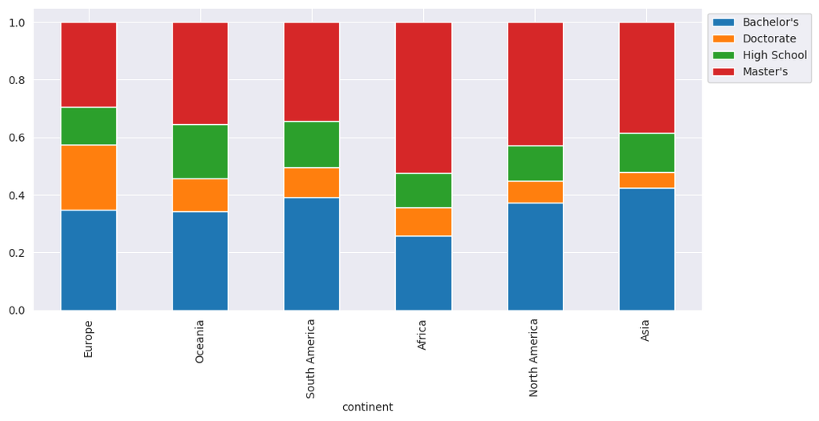

```python
#create a stacked barplot of continent and employee education
stacked_barplot(viz_data, "continent", "education_of_employee")
```

### Observations on `has_job_experience` and `continent`

```
has_job_experience      N      Y    All
continent
All                 10678  14802  25480
Asia                 7071   9790  16861
Europe               1576   2156   3732
North America        1348   1944   3292
South America         377    475    852
Africa                217    334    551
Oceania                89    103    192
------------------------------------------------------------------------------------------------------------------------
```

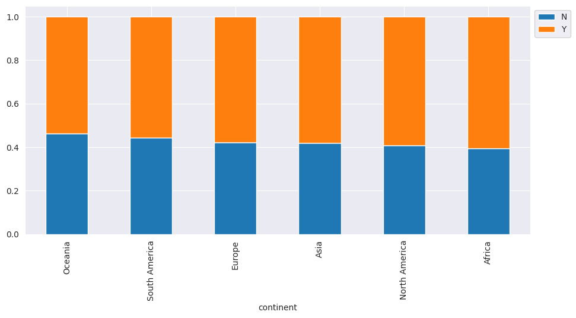

```python
#stacked barplot of continent and has_job_experience
stacked_barplot(viz_data, "continent", "has_job_experience")
```

While there is some difference overall that may show up in a statistical test (such as chi-square), visually the origin continent does not seem to affect whether an applicant has prior job experience.

### Observations on `continent` and `requires_job_training`

```
requires_job_training      N     Y    All
continent
All                    22525  2955  25480
Asia                   15113  1748  16861
Europe                  2993   739   3732
North America           3044   248   3292
South America            702   150    852
Africa                   510    41    551
Oceania                  163    29    192
------------------------------------------------------------------------------------------------------------------------
```

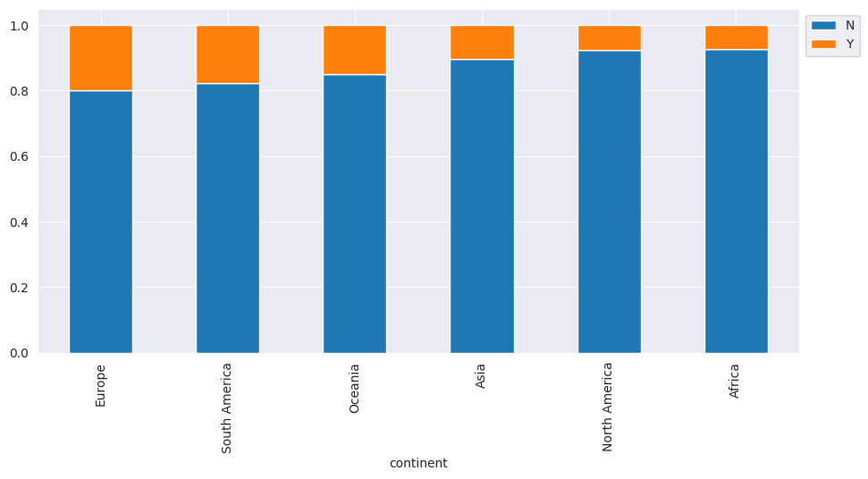

```python
#stacked barplot for continent and requires_job_training
stacked_barplot(viz_data, "continent", "requires_job_training")
```

There is a visual difference here. The vast majority of all applicants do not need job training. However, of those that do, only a low proportion of applicants from Africa require job training. Europe boasts the largest pool of applicants who require job training at nearly 20%.

### Observations on `continent` and `region_of_employment`

```
region_of_employment  Island  Midwest  Northeast  South  West    All
continent
All                      375     4307       7195   7017  6586  25480
Asia                     226     3371       4589   4805  3870  16861
North America             82      392       1114    870   834   3292
Europe                    32      303        965    973  1459   3732
South America             23      111        266    223   229    852
Africa                     8       92        212    102   137    551
Oceania                    4       38         49     44    57    192
------------------------------------------------------------------------------------------------------------------------
```

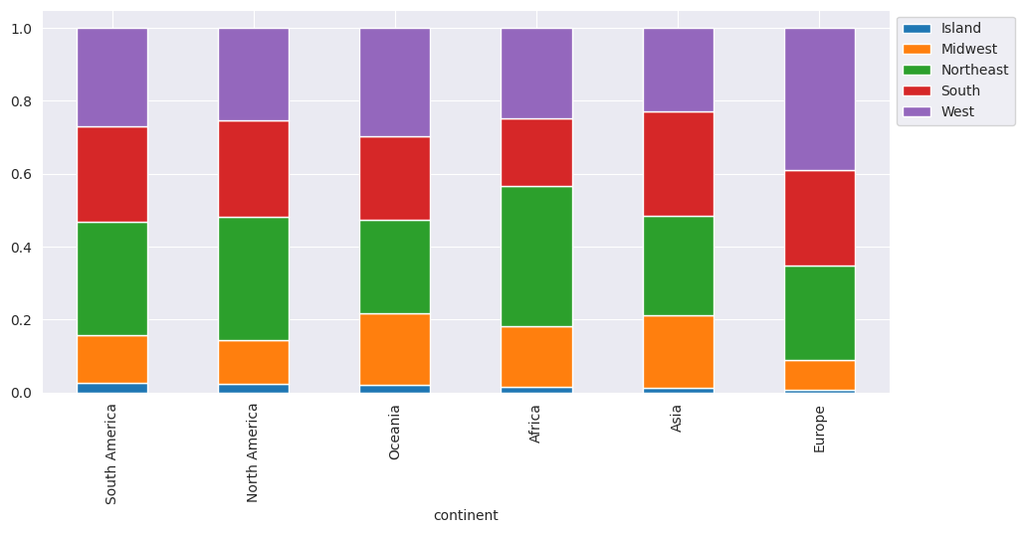

```python
#stacked bargraph with continent and region_of_employment
stacked_barplot(viz_data, "continent", "region_of_employment")
```

I expected this to be fairly uniform but it is not.

- A higher proportion of Europeans apply for jobs in the west region of the US
- The lowest proportion of jobs located in the south region come from Africa
- Applicants from Oceania and Asia are more likely to be applying for jobs in the midwest
- African applicants default to the Northeast.
- Applicants for the Island regions are small no matter the continent of origin.

### Observations on `Continent` and `full_time_position`

```
full_time_position     N      Y    All
continent
All                 2707  22773  25480
Asia                1941  14920  16861
North America        571   2721   3292
Europe               115   3617   3732
Africa                31    520    551
South America         31    821    852
Oceania               18    174    192
------------------------------------------------------------------------------------------------------------------------
```

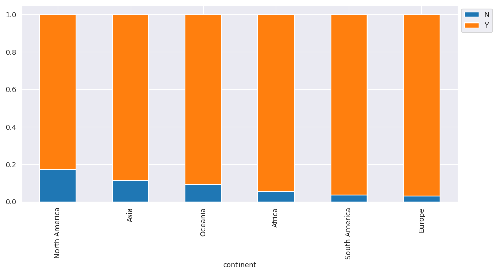

```python
#stacked bargraph with continent and full_time_position
stacked_barplot(viz_data, "continent", "full_time_position")
```

The vast majority of all applicants are applying for full time work. However, North American applicants comprise the continent with the higher proportion of part-time work. European applicants are the lowest percentage of part-time applicants.

### Observations on `unit_of_wage` and `full_time_position`

```
full_time_position     N      Y    All
unit_of_wage
All                 2707  22773  25480
Year                2673  20289  22962
Hour                  19   2138   2157
Week                  10    262    272
Month                  5     84     89
------------------------------------------------------------------------------------------------------------------------
```

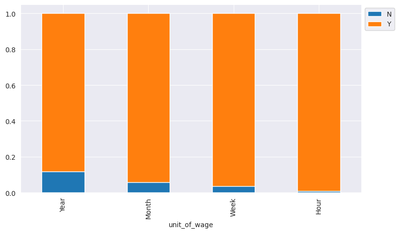

```python
#stacked barplot of unit_of_wage and full_time_position
stacked_barplot(viz_data, "unit_of_wage", "full_time_position")
```

Most applicants had full time jobs, however, for both types of position, wages were reported in a variety of units. Consolidating these units will be helpful in feature engineering.

### Observations on `continent` and `case_status`

```
case_status    Certified  Denied    All
continent
All                17018    8462  25480
Asia               11012    5849  16861
North America       2037    1255   3292
Europe              2957     775   3732
South America        493     359    852
Africa               397     154    551
Oceania              122      70    192
------------------------------------------------------------------------------------------------------------------------
```

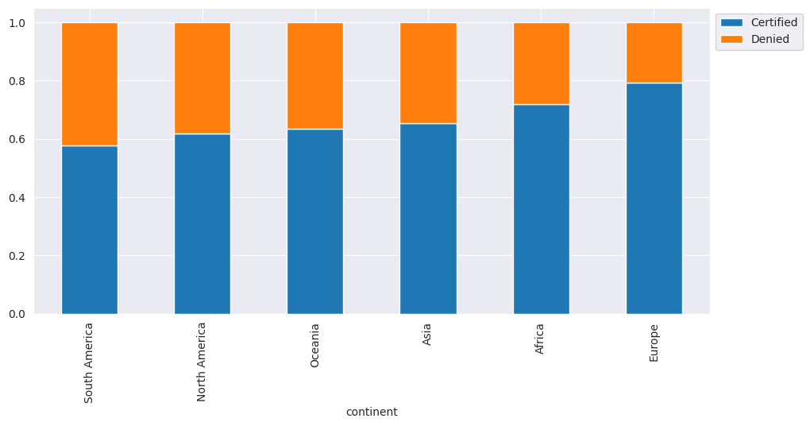

```python
#stacked bargraph of continent and case_status
stacked_barplot(viz_data, "continent", "case_status")
```

`case_status` is the target variable. South America has the highest proportion of Denied applicants. Europe has the lower proportion of denied applicants. This suggests that continent of origin may have some impact in the decision prediction.

### Observations on `education_of_employee` and `case_status`

```
case_status            Certified  Denied    All
education_of_employee
All                        17018    8462  25480
Bachelor's                  6367    3867  10234
High School                 1164    2256   3420
Master's                    7575    2059   9634
Doctorate                   1912     280   2192
------------------------------------------------------------------------------------------------------------------------
```

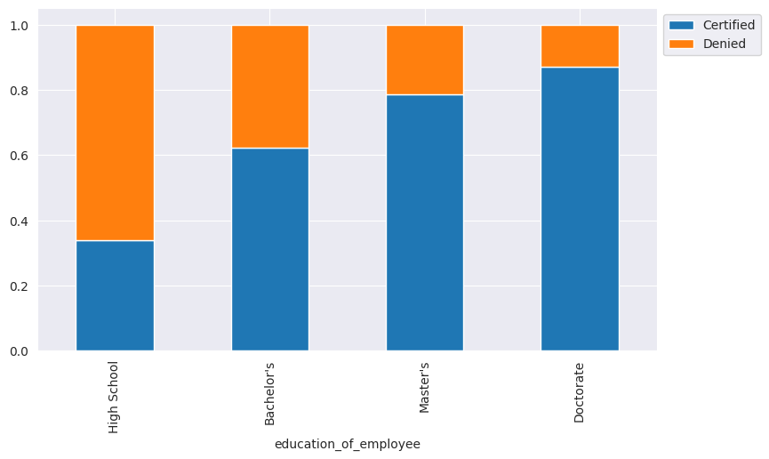

```python
#stacked barplot showing education_of_employee and case_status
stacked_barplot(viz_data, "education_of_employee", "case_status")
```

The education level of visa applicants appears to be greatly impacted by the level of education of the applicant. High School educated applicants have the highest rate of denials, while doctorate holders have the highest rate of certified status. As the level of education increases, so too does the number of approved visas.

### Observations on `case_status` and `full_time_position`

```
case_status         Certified  Denied    All
full_time_position
All                     17018    8462  25480
Y                       15163    7610  22773
N                        1855     852   2707
------------------------------------------------------------------------------------------------------------------------
```

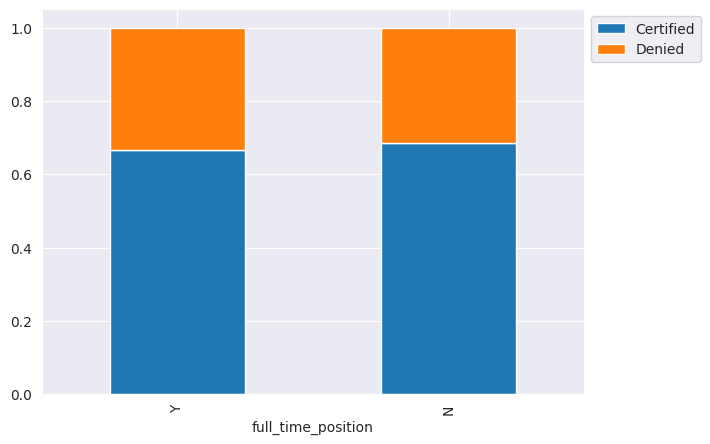

```python
#stacked bargraph for case_status and full_time_position
stacked_barplot(viz_data, "full_time_position", "case_status")
```

Visually there does not appear to be a difference in the type of position being applied for the the case_decision. I expect part-time and full-time employement to have a lower effect on the categorization of the data.

### Observations on `case_status` and `unit_of_wage`

```
case_status   Certified  Denied    All
unit_of_wage
All               17018    8462  25480
Year              16047    6915  22962
Hour                747    1410   2157
Week                169     103    272
Month                55      34     89
------------------------------------------------------------------------------------------------------------------------
```

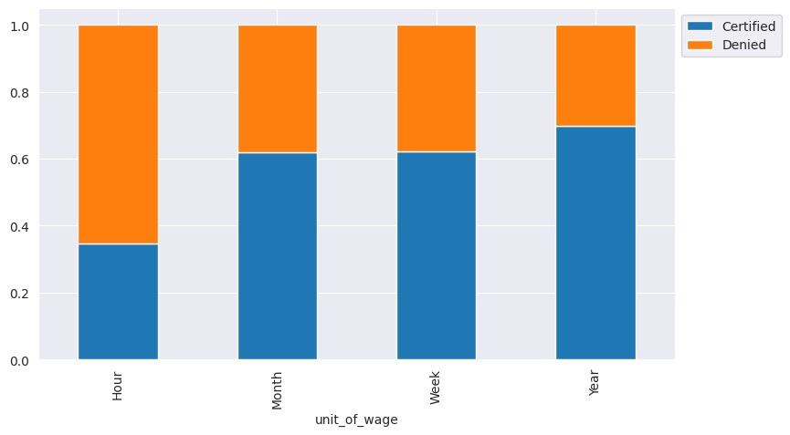

```python
#stacked bargraph with unit_of_wage and case_status
stacked_barplot(viz_data, "unit_of_wage", "case_status")
```

Workers who are offered pay at the hourly rate are signficantly more likely to be denied a visa compared to weely, monthly or yearly. Applicants who are offered an annual salary have the higher proportion of certified application decisions.

### Observations on `case_status` and `region_of_employment`

```
case_status           Certified  Denied    All
region_of_employment
All                       17018    8462  25480
Northeast                  4526    2669   7195
West                       4100    2486   6586
South                      4913    2104   7017
Midwest                    3253    1054   4307
Island                      226     149    375
------------------------------------------------------------------------------------------------------------------------
```

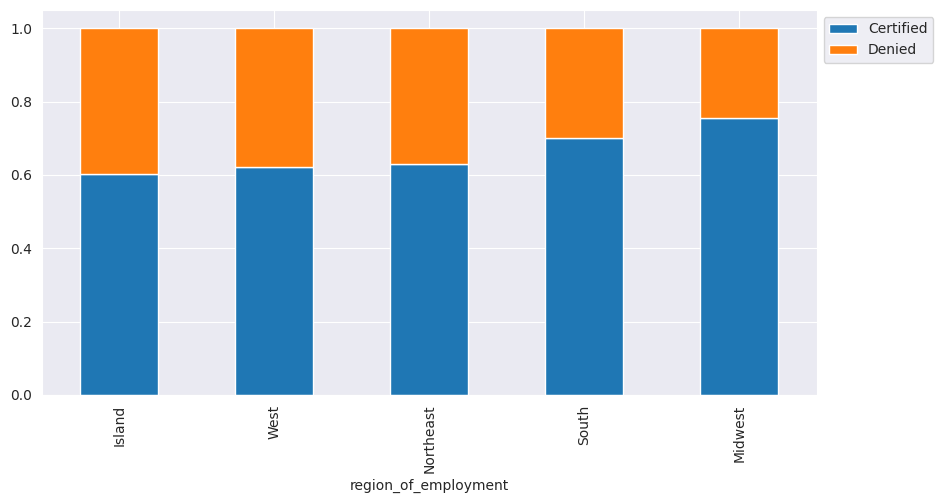

```python
#stacked bargraph of region_of_employment and case_status
stacked_barplot(viz_data, "region_of_employment", "case_status")
```

While there does not appear to be a strong difference, the south and midwest regions have a lower proportion of denied visas than the other regions do. While this is worth exploring more, a plausible explanation could be the higher need for jobs in these two less urban regions of the US.

### Observations on `requires_job_training` and `case_status`

```
case_status            Certified  Denied    All
requires_job_training
All                        17018    8462  25480
N                          15012    7513  22525
Y                           2006     949   2955
------------------------------------------------------------------------------------------------------------------------
```

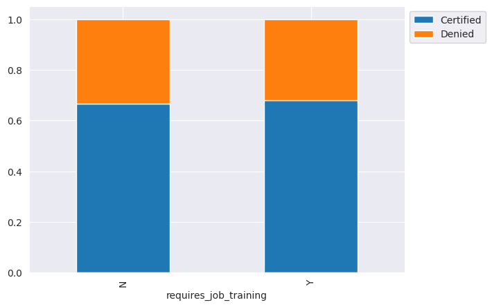

```python
#stacked bargraph of requires_job_training and case_status
stacked_barplot(viz_data, "requires_job_training", "case_status")
```

The need for job training does not appear to factor into certification decisions.

### Observations on `has_job_experience` and `case_status`

```
case_status         Certified  Denied    All
has_job_experience
All                     17018    8462  25480
N                        5994    4684  10678
Y                       11024    3778  14802
------------------------------------------------------------------------------------------------------------------------
```

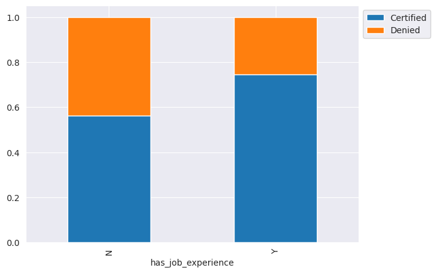

```python
#stacked bargraph on has_job_experience and case_status
stacked_barplot(viz_data, "has_job_experience", "case_status")
```

Job experience seems to play a role in the visa decision process. Applicants how have prior job experience are more likely to have their visas certified than are appliants with no prior experience.

### Observations on `case_status` and `no_of_employees`

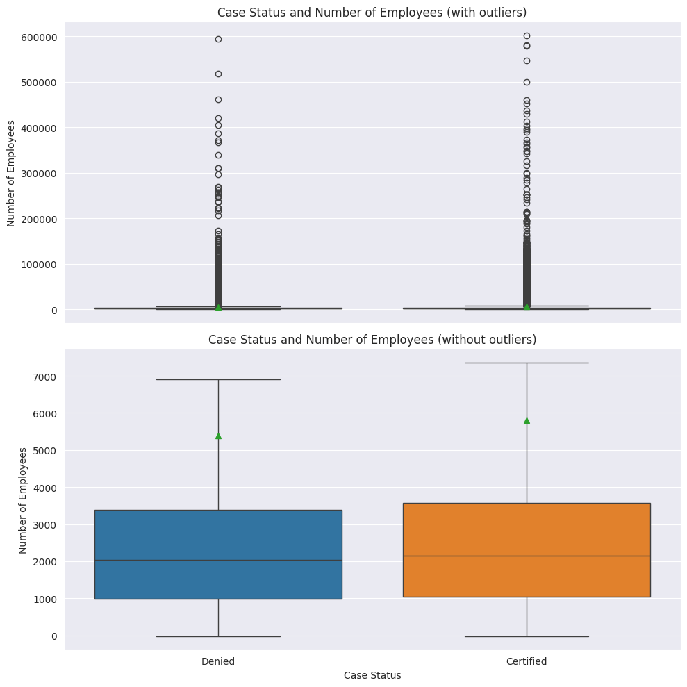

```python
fig, axes = plt.subplots(2, 1, figsize=(10, 10), sharex=True) # 2 rows, 1 column, sharing x-axis

# Subplot 1: Boxplot with outliers
sns.boxplot(data=viz_data, x='case_status', y='no_of_employees', showmeans=True, hue='case_status', ax=axes[0], legend=False)
axes[0].set_title('Case Status and Number of Employees (with outliers)')
axes[0].set_xlabel('') # Remove x-label for the top plot
axes[0].set_ylabel('Number of Employees')
axes[0].ticklabel_format(style='plain', axis='y')

# Subplot 2: Boxplot without outliers
sns.boxplot(data=viz_data, x='case_status', y='no_of_employees', showmeans=True, hue='case_status', showfliers=False, ax=axes[1], legend=False)
axes[1].set_title('Case Status and Number of Employees (without outliers)')
axes[1].set_xlabel('Case Status')
axes[1].set_ylabel('Number of Employees')
axes[1].ticklabel_format(style='plain', axis='y')

plt.tight_layout()
plt.show()
```

```python
#descriptive statistics of number of employees grouped by case_status
viz_data.groupby("case_status")["no_of_employees"].describe().T
```

| case_status | Certified | Denied |
| --- | --- | --- |
| count | 17018.00 | 8462.00 |
| mean | 5807.02 | 5385.54 |
| std | 23119.58 | 22382.76 |
| min | -26.00 | -26.00 |
| 25% | 1035.25 | 991.00 |
| 50% | 2147.00 | 2032.50 |
| 75% | 3575.00 | 3386.75 |
| max | 602069.00 | 594472.00 |

I ran this twice, once with and once without the outliers. In both cases, the size of the company, based on the number of employees, does not appear to have a significant effect on the visa decision. The one point of interest is the negative number of of employees show as the minimum in both groups. This is worth exploring in the data pre-processing stage.

### Observations on `year_of_establishment` and `case_status`

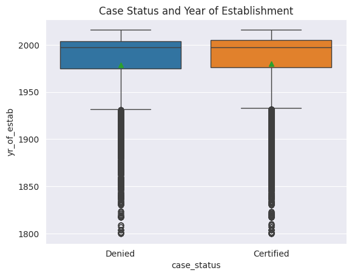

```python
sns.boxplot(data = viz_data, x = "case_status", y = "yr_of_estab", showmeans = True, hue="case_status")
plt.title("Case Status and Year of Establishment")
plt.show()
```

The year a company was established does not appear to affect the visa decision.

### Observations on `prevailing_wage` and `case_status`

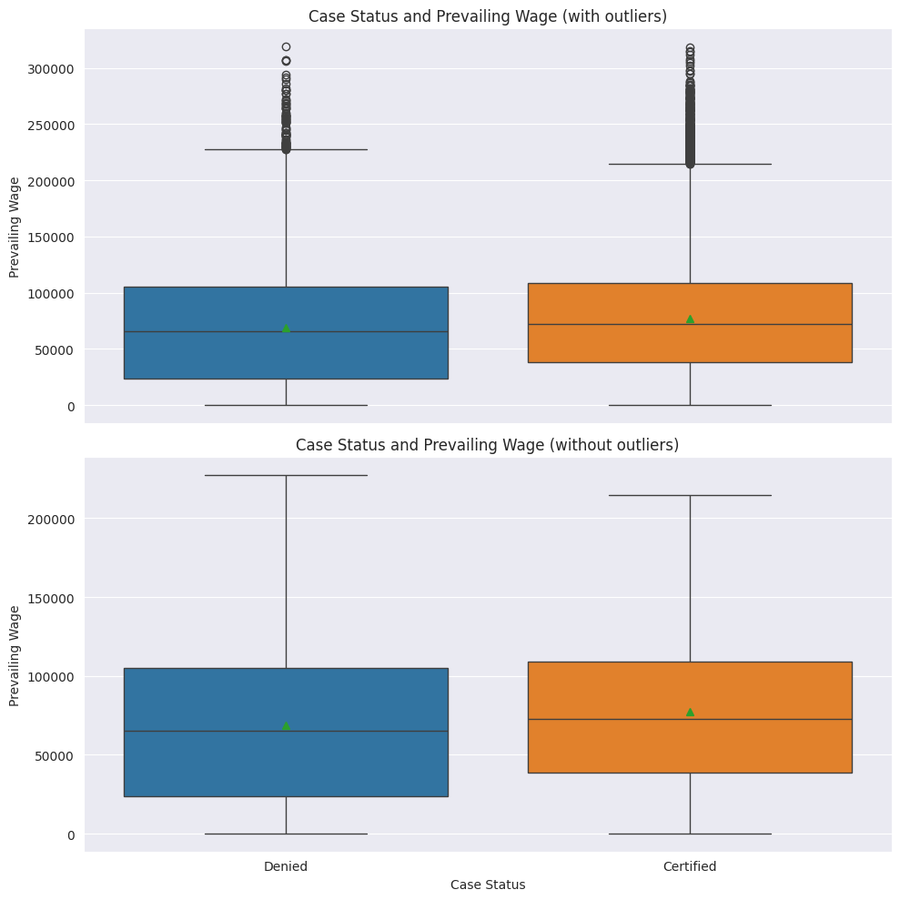

```python
fig, axes = plt.subplots(2, 1, figsize=(10, 10), sharex=True) # 2 rows, 1 column, sharing x-axis

# Subplot 1: Boxplot with outliers
sns.boxplot(data=viz_data, x='case_status', y='prevailing_wage', showmeans=True, hue='case_status', ax=axes[0], legend=False)
axes[0].set_title('Case Status and Prevailing Wage (with outliers)')
axes[0].set_xlabel('') # Remove x-label for the top plot
axes[0].set_ylabel('Prevailing Wage')
axes[0].ticklabel_format(style='plain', axis='y')

# Subplot 2: Boxplot without outliers
sns.boxplot(data=viz_data, x='case_status', y='prevailing_wage', showmeans=True, hue='case_status', showfliers=False, ax=axes[1], legend=False)
axes[1].set_title('Case Status and Prevailing Wage (without outliers)')
axes[1].set_xlabel('Case Status')
axes[1].set_ylabel('Prevailing Wage')
axes[1].ticklabel_format(style='plain', axis='y')

plt.tight_layout()
plt.show()
```

```python
#show the numeric summary of prevailing_wage grouped by case_status
viz_data.groupby("case_status")["prevailing_wage"].describe().T
```

| case_status | Certified | Denied |
| --- | --- | --- |
| count | 17018.00 | 8462.00 |
| mean | 77293.62 | 68748.68 |
| std | 52042.72 | 53890.17 |
| min | 2.14 | 2.96 |
| 25% | 38375.33 | 23497.29 |
| 50% | 72486.27 | 65431.46 |
| 75% | 108879.11 | 105097.64 |
| max | 318446.05 | 319210.27 |

I appears that both the mean and median prevailing_wage is higher for certified visa decisions. However, there is significant overlap at both the high and the low end of the scale. Without running a t.test or similar statical inference test, it is impossible to determine if these are signficantly different.

### Observations on `prevailing_wage` and `full_time_status`

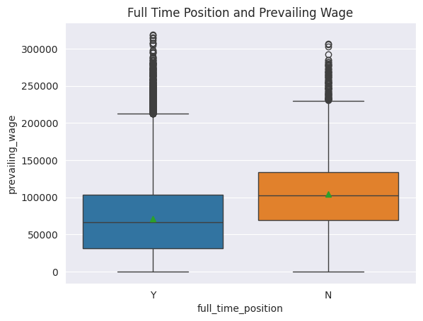

```
full_time_position         N         Y
count                2707.00  22773.00
mean               104745.40  70855.33
std                 52799.53  51651.00
min                    98.60      2.14
25%                 68947.62  30797.94
50%                102446.51  66392.67
75%                133465.05 103421.73
max                306206.67 319210.27
```

```python
#group prevailing wage by full_time_position
#calculate summary statistics and side by side boxplots
sns.boxplot(data = viz_data, x = "full_time_position", y = "prevailing_wage", showmeans = True, hue="full_time_position")
plt.title("Full Time Position and Prevailing Wage")
plt.show()
print(viz_data.groupby("full_time_position")["prevailing_wage"].describe().T)
```

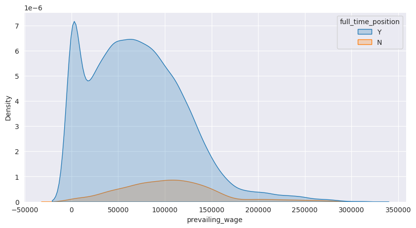

```python
#show density plot for prevailing_wage and full_time_position on a single graph
plt.figure(figsize = (10, 5))
sns.kdeplot(data = viz_data, x = "prevailing_wage", hue = "full_time_position", fill=True)
plt.show()
```

```python
#display the rows with the ten lowest prevailing_wage
viz_data.nsmallest(100, "prevailing_wage")
```

|  | case_id | continent | education_of_employee | has_job_experience | requires_job_training | no_of_employees | yr_of_estab | region_of_employment | prevailing_wage | unit_of_wage | full_time_position | case_status |
| --- | --- | --- | --- | --- | --- | --- | --- | --- | --- | --- | --- | --- |
| 20575 | EZYV20576 | North America | Master's | N | N | 1552 | 2004 | Northeast | 2.14 | Hour | Y | Certified |
| 22855 | EZYV22856 | North America | High School | Y | N | 564 | 1991 | South | 2.96 | Hour | Y | Denied |
| 17448 | EZYV17449 | South America | Master's | Y | N | 4421 | 1999 | Northeast | 3.00 | Hour | Y | Denied |
| 634 | EZYV635 | Asia | Master's | N | N | 834 | 1977 | Northeast | 3.32 | Hour | Y | Denied |
| 5455 | EZYV5456 | North America | Doctorate | Y | Y | 2038 | 2007 | Northeast | 3.49 | Hour | Y | Certified |
| ... | ... | ... | ... | ... | ... | ... | ... | ... | ... | ... | ... | ... |
| 1346 | EZYV1347 | Asia | Master's | N | N | 56 | 2001 | West | 51.68 | Hour | Y | Denied |
| 4255 | EZYV4256 | Asia | Bachelor's | N | N | 22 | 2010 | Northeast | 51.85 | Hour | Y | Denied |
| 20464 | EZYV20465 | North America | Master's | N | N | 1154 | 1977 | South | 52.05 | Hour | Y | Denied |
| 20772 | EZYV20773 | Asia | High School | N | N | 1131 | 2001 | Island | 52.82 | Hour | Y | Denied |
| 5545 | EZYV5546 | Africa | Bachelor's | N | N | 2512 | 1968 | Midwest | 52.85 | Hour | Y | Denied |

100 rows × 12 columns

There is significant overlap in the wages between full time and part time positions. Both are right skewed and the ranges are nearly identical. Oddly, the lowest wage (though not technically classifed as an outlier) of $2.1367 is from the full tiem group. This number is a bit odd since it is clearly a wage that has been adjust to show hourly (since the USA only uses cents out to the hundredths decimal place). This suggests that prevailing_wage will end up not being a very useful analysis category without feature engineering.

## Feature Engineering on `prevailing_wage`

The goal of this code to to adjust prevailing wage into all the same unit of measure, whether yearly or annual. Since there is a relatively high number of part time positions, it only makes sense to adjust the wage to an annual rate.

```python
# 1) copy the dataframe to a new one called test_data
test_data = viz_data.copy()
```

```python
# 2) copy the prevailing_wage column to a new column titled adj_wage
test_data['adj_wage'] = test_data['prevailing_wage'].copy()

# Clean the 'unit_of_wage' column first for consistent comparisons
test_data['unit_of_wage'] = test_data['unit_of_wage'].str.strip().str.lower()

# 3) if the unit_of_wage = "hour" and if full_time_position = "Y", then multiply the corresponding value of adj_wage
# using this formula: adj_wage = adj_wage * 40 * 52 and overwrite the original value of adj_wage
test_data.loc[
    (test_data['unit_of_wage'] == 'hour') & (test_data['full_time_position'] == 'Y'),
    'adj_wage'
] = test_data['adj_wage'] * 40 * 52
test_data.loc[(test_data['unit_of_wage']== 'hour') & (test_data["full_time_position"] == 'Y'), 'unit_of_wage'] = "year"

# 4) if the unit_of_wage = "week" then multiply using the formula: adj_wage = adj_wage * 52
test_data.loc[(test_data['unit_of_wage'] == 'week'),'adj_wage'] = test_data['adj_wage'] * 52
test_data.loc[(test_data['unit_of_wage']== 'week'), 'unit_of_wage'] = "year"

# 5) if the unit_of_wage = "month"  then use the formula adj_wage = adj_wage * 12
test_data.loc[(test_data['unit_of_wage'] == 'month'),'adj_wage'] = test_data['adj_wage'] * 12
test_data.loc[(test_data['unit_of_wage']== 'month'), 'unit_of_wage'] = "year"


display(test_data.head())
```

|  | case_id | continent | education_of_employee | has_job_experience | requires_job_training | no_of_employees | yr_of_estab | region_of_employment | prevailing_wage | unit_of_wage | full_time_position | case_status | adj_wage |
| --- | --- | --- | --- | --- | --- | --- | --- | --- | --- | --- | --- | --- | --- |
| 0 | EZYV01 | Asia | High School | N | N | 14513 | 2007 | West | 592.20 | year | Y | Denied | 1231782.03 |
| 1 | EZYV02 | Asia | Master's | Y | N | 2412 | 2002 | Northeast | 83425.65 | year | Y | Certified | 83425.65 |
| 2 | EZYV03 | Asia | Bachelor's | N | Y | 44444 | 2008 | West | 122996.86 | year | Y | Denied | 122996.86 |
| 3 | EZYV04 | Asia | Bachelor's | N | N | 98 | 1897 | West | 83434.03 | year | Y | Denied | 83434.03 |
| 4 | EZYV05 | Africa | Master's | Y | N | 1082 | 2005 | South | 149907.39 | year | Y | Certified | 149907.39 |

```
full_time_position     N      Y    All
unit_of_wage
All                 2707  22773  25480
year                2688  22773  25461
hour                  19      0     19
------------------------------------------------------------------------------------------------------------------------
```

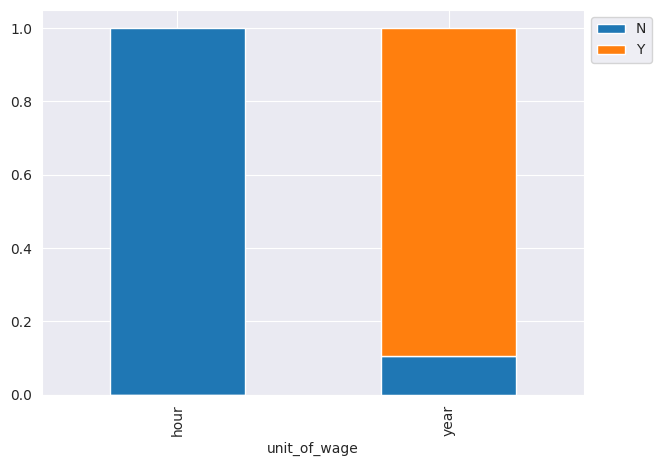

```python
#display a stacked barchart of unit_of_wage and full_time_status
stacked_barplot(test_data, "unit_of_wage", "full_time_position")
```

There are still 19 positions are are labeled as hourly and and part-time. Since the number of hours on offer are not included in this data set, and since 19 is a relatively small proportion of the data set, the decision has been made to drop these values.

```python
#drop the 19 rows that have a unit_of_wage of an hour
test_data = test_data[test_data["unit_of_wage"] != "hour"]
```

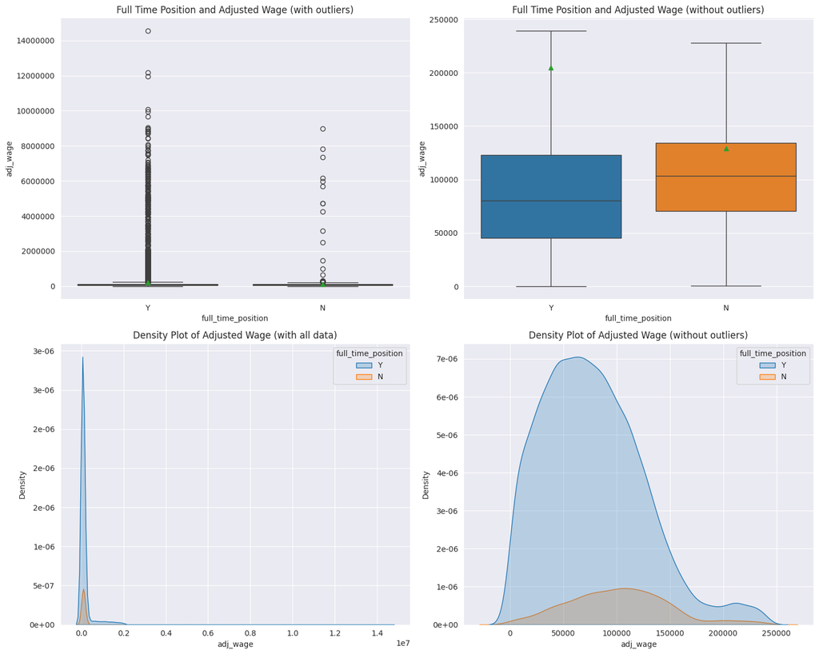

```python
#visualize adj_wage grouped by full_time_position
import matplotlib.ticker as mticker

# Create a 2x2 grid of subplots
fig, axes = plt.subplots(2, 2, figsize=(15, 12))

# First subplot (top-left): original boxplot with no scientific notation and integer display
sns.boxplot(data=test_data, x="full_time_position", y="adj_wage", showmeans=True, hue="full_time_position", ax=axes[0, 0], legend=False)
axes[0, 0].set_title("Full Time Position and Adjusted Wage (with outliers)")
axes[0, 0].yaxis.set_major_formatter(mticker.FormatStrFormatter('%d'))

# Second subplot (top-right): boxplot without outliers, no scientific notation, and integer display
sns.boxplot(data=test_data, x="full_time_position", y="adj_wage", showmeans=True, hue="full_time_position", showfliers=False, ax=axes[0, 1], legend=False)
axes[0, 1].set_title("Full Time Position and Adjusted Wage (without outliers)")
axes[0, 1].yaxis.set_major_formatter(mticker.FormatStrFormatter('%d'))

# Third subplot (bottom-left): KDE plot corresponding to the first boxplot
sns.kdeplot(data=test_data, x="adj_wage", hue="full_time_position", fill=True, ax=axes[1, 0])
axes[1, 0].set_title("Density Plot of Adjusted Wage (with all data)")
axes[1, 0].yaxis.set_major_formatter(mticker.FormatStrFormatter('%.0e')) # scientific for density as it's small

# Fourth subplot (bottom-right): KDE plot for data without outliers
# Filter test_data to remove outliers based on the same logic used for viz_data_trimmed earlier,
# or re-calculate for test_data if 'adj_wage' has different outlier characteristics.
# For now, let's assume we want to show the KDE for the original data to match the first boxplot, or filter the outliers here.
# A more robust approach might re-calculate IQR for 'adj_wage' in test_data.

# Calculate IQR for 'adj_wage' in test_data for accurate outlier removal for the KDE plot
Q1_adj = test_data['adj_wage'].quantile(0.25)
Q3_adj = test_data['adj_wage'].quantile(0.75)
IQR_adj = Q3_adj - Q1_adj
lower_bound_adj = Q1_adj - 1.5 * IQR_adj
upper_bound_adj = Q3_adj + 1.5 * IQR_adj

test_data_trimmed_adj = test_data[(test_data['adj_wage'] >= lower_bound_adj) & (test_data['adj_wage'] <= upper_bound_adj)]

sns.kdeplot(data=test_data_trimmed_adj, x="adj_wage", hue="full_time_position", fill=True, ax=axes[1, 1])
axes[1, 1].set_title("Density Plot of Adjusted Wage (without outliers)")
axes[1, 1].yaxis.set_major_formatter(mticker.FormatStrFormatter('%.0e'))

plt.tight_layout()
plt.show()
```

There is still significant overlap in both the part time and full time job categories, suggest that the feature engineering did not introduce any unintentional skew into the data.

```python
# Define the new categories
new_categories = ["low", "below average", "average", "above average", "high"]

# Create a CategoricalDtype object with the desired categories and order
wage_cat_dtype = pd.CategoricalDtype(categories=new_categories, ordered=True)

# using the adj_wage, split it into 5 categories with explicit labels and dtype
test_data.loc[:, "wage_category"] = pd.qcut(
    test_data["adj_wage"], 5, labels=new_categories
).astype(wage_cat_dtype)

test_data["wage_category"].value_counts()
```

| wage_category | count |
| --- | --- |
| low | 5093 |
| below average | 5092 |
| average | 5092 |
| above average | 5092 |
| high | 5092 |

**dtype:** int64

```python
#display a count of the number of adj_wage values that are less than $30000
count_less_than_30k = test_data[test_data['adj_wage'] < 30000].shape[0]
count_less_than_20k = test_data[test_data['adj_wage'] < 20000].shape[0]
count_less_than_10k = test_data[test_data['adj_wage'] < 10000].shape[0]
print(f"Number of 'adj_wage' values less than $30,000: {count_less_than_30k}")
print(f"Number of 'adj_wage' values less than $20,000: {count_less_than_20k}")
print(f"Number of 'adj_wage' values less than $10,000: {count_less_than_10k}")
```

```
Number of 'adj_wage' values less than $30,000: 3561
Number of 'adj_wage' values less than $20,000: 2192
Number of 'adj_wage' values less than $10,000: 1043
```

Having worked overseas myself, I know that there is often a minimal salary threshhold for obtaining a post. As a result, many of the lower values in the adjusted wage category seem suspect (such as the $99.999 annual wage). The confusion may have resulted from the fact that the USA uses a comma (,) to separate groups of thousands while other countries use periods (.) for this same principle. However, there are a very high number of adj_wage values that are less than $30,000. without more information, any more adjustment to this column would be arbitrary. There is too much data to drop. As a result, these values, though odd, will remain.

```
full_time_position     N      Y    All
wage_category
All                 2688  22773  25461
above average        845   4247   5092
high                 621   4471   5092
average              571   4521   5092
below average        411   4681   5092
low                  240   4853   5093
------------------------------------------------------------------------------------------------------------------------
```

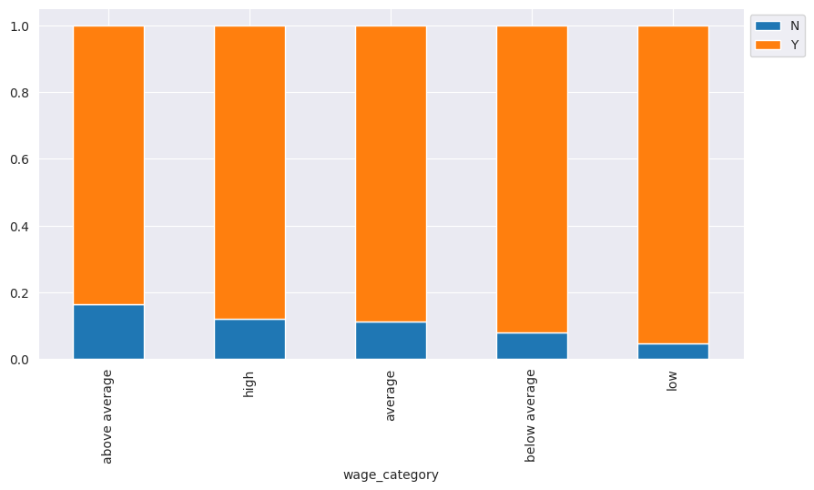

```python
#stacked barplot for wage_categry and full_time_position
stacked_barplot(test_data, "wage_category", "full_time_position")
```

### Observations on `case_status` and `wage_category`

```
case_status    Certified  Denied    All
wage_category
All                17015    8446  25461
high                2834    2258   5092
above average       3453    1639   5092
average             3507    1585   5092
below average       3575    1517   5092
low                 3646    1447   5093
------------------------------------------------------------------------------------------------------------------------
```

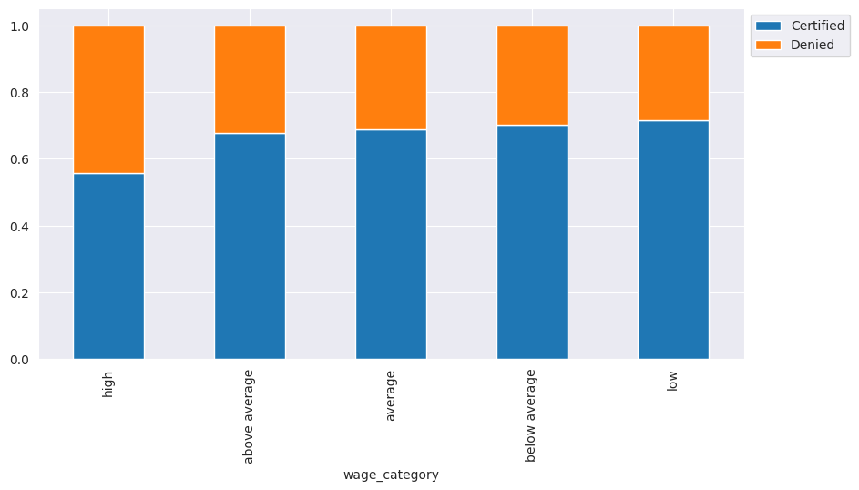

```python
#stacked barplot for case_status and wage_category
stacked_barplot(test_data, "wage_category", "case_status")
```

Interestingly, the high wage category has the highest number of cases denied. The other four wage categories are visiually equivalent.

### Observations on `case_status`, `full_time_position`, and `wage_category`

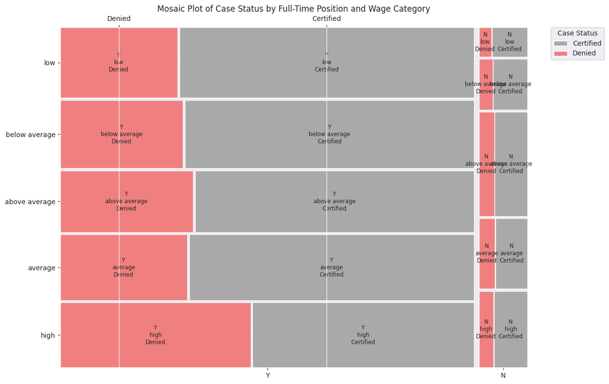

```python
from statsmodels.graphics.mosaicplot import mosaic
from matplotlib.patches import Patch

# Increase width of the graph
plt.rcParams['figure.figsize'] = (15, 8)

# Define custom colors
colors_map = {
    'Certified': 'darkgray',    # Dark gray for Certified
    'Denied': 'lightcoral'    # Pale red/orange for Denied
}

# Function to apply custom colors to the mosaic plot tiles
def properties_func_updated(key):
    status = key[-1] # Get the 'case_status' value from the key
    return {'facecolor': colors_map.get(status, 'lightgray'), 'edgecolor': 'white'}

# Create the mosaic plot
# The mosaic function returns the Figure (fig) and a dictionary of rectangles (rect_dict).
# The Axes object needs to be explicitly retrieved from the Figure.
fig, rect_dict = mosaic(test_data, ['full_time_position', 'wage_category', 'case_status'],
                     properties=properties_func_updated, # Apply custom coloring
                     title='Mosaic Plot of Case Status by Full-Time Position and Wage Category',
                     gap=0.01)

# Get the Axes object from the Figure
ax = fig.gca()

# Add a key (legend) to explain the color coding
legend_elements = [Patch(facecolor=colors_map[status], label=status)
                   for status in colors_map]

ax.legend(handles=legend_elements, title="Case Status", bbox_to_anchor=(1.05, 1), loc='upper left', borderaxespad=0.)

# Ensure the layout is tight to prevent labels/legend from being cut off
plt.tight_layout(rect=[0, 0, 0.85, 1]) # Adjust rect to make space for the legend on the right

plt.show()
```

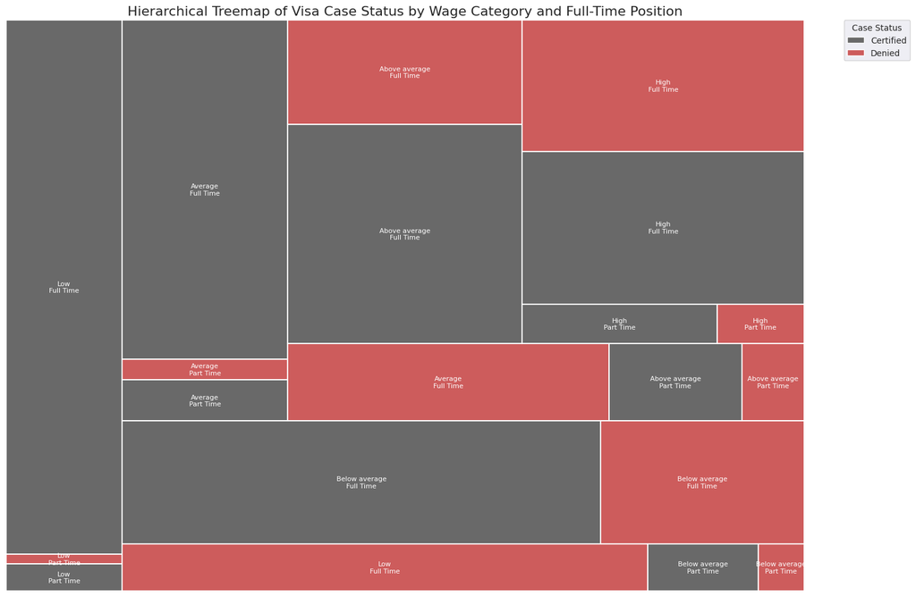

```python
# Prepare data: Group by the hierarchical levels and count occurrences
# Ensure 'full_time_position' and 'case_status' are categorical for consistent sorting.
# 'wage_category' is already an ordered categorical type from a previous step.
if not isinstance(test_data['full_time_position'].dtype, pd.CategoricalDtype):
    test_data['full_time_position'] = test_data['full_time_position'].astype('category')
if not isinstance(test_data['case_status'].dtype, pd.CategoricalDtype):
    test_data['case_status'] = test_data['case_status'].astype('category')

treemap_data = test_data.groupby(['wage_category', 'full_time_position', 'case_status'], observed=True).size().reset_index(name='size')

# Sort data to encourage squarify to group related items visually. This helps in perceiving
# the hierarchy without explicit labels on the blocks
treemap_data = treemap_data.sort_values(by=['wage_category', 'full_time_position', 'case_status'], ascending=[True, True, True])

# Define colors for case_status (the lowest level of hierarchy, for which a key is made)
colors_map = {
    'Certified': 'dimgray',    # Darker gray for Certified
    'Denied': 'indianred'     # Darker red for Denied
}
treemap_data['color'] = treemap_data['case_status'].map(colors_map)

# Create a mapping for full_time_position labels
position_map = {
    'Y': 'Full Time',
    'N': 'Part Time'
}

# Create labels for each treemap block, excluding case_status and mapping full_time_position
treemap_data['label'] = treemap_data.apply(lambda x: f"{x['wage_category'].capitalize()}\n{position_map.get(x['full_time_position'], x['full_time_position'])}", axis=1)

# Create a list of sizes, colors, and labels for squarify
sizes = treemap_data['size'].tolist()
colors = treemap_data['color'].tolist()
labels = treemap_data['label'].tolist()

# Set up the plot
plt.figure(figsize=(18, 10)) # Increased width for better visualization
ax = plt.gca() # Get current axes

# Plot treemap - explicitly disable labels on the graphic as requested
squarify.plot(sizes=sizes, color=colors, ax=ax, label=labels, bar_kwargs={'edgecolor': 'white', 'linewidth': 1.5}, text_kwargs={'fontsize': 8, 'color': 'white'})

# Set the title to act as the primary 'axis label' for the treemap, indicating the hierarchy
plt.title('Hierarchical Treemap of Visa Case Status by Wage Category and Full-Time Position', fontsize=16)

# Create custom legend for case_status color coding
legend_elements = [Patch(facecolor=colors_map[status], label=status)
                   for status in colors_map]
ax.legend(handles=legend_elements, title="Case Status", bbox_to_anchor=(1.05, 1), loc='upper left', borderaxespad=0.)

# Remove axes ticks and labels as they are not meaningful for treemaps and user requested no labels on graphic itself
ax.set_xticks([])
ax.set_yticks([])
ax.set_xticklabels([])
ax.set_yticklabels([])

# Ensure tight layout and make space for the legend
plt.tight_layout(rect=[0, 0, 0.85, 1])

plt.show()
```

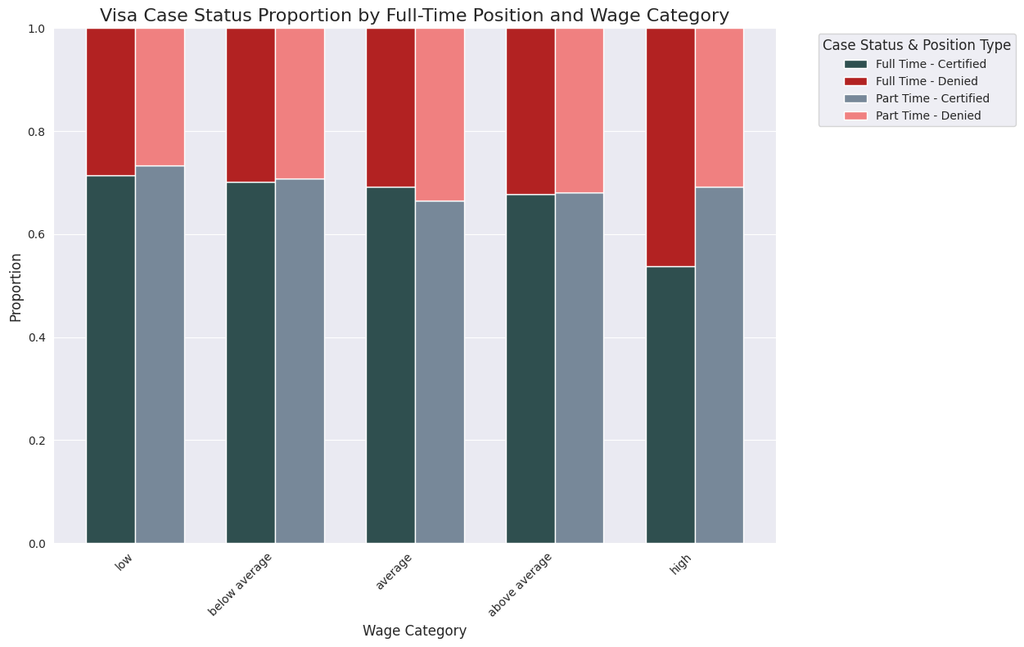

```python
# Ensure 'wage_category', 'full_time_position', and 'case_status' are categorical
# 'wage_category' is already ordered from previous steps.
if not isinstance(test_data['full_time_position'].dtype, pd.CategoricalDtype):
    test_data['full_time_position'] = test_data['full_time_position'].astype('category')
if not isinstance(test_data['case_status'].dtype, pd.CategoricalDtype):
    test_data['case_status'] = test_data['case_status'].astype('category')

# Create a mapping for full_time_position labels (Y/N to Full Time/Part Time)
position_map = {
    'Y': 'Full Time',
    'N': 'Part Time'
}
test_data['full_time_position_label'] = test_data['full_time_position'].map(position_map).astype('category')

# Group data to get counts for each combination of wage_category, full_time_position_label, and case_status
plot_df_counts = test_data.groupby(['wage_category', 'full_time_position_label', 'case_status'], observed=True).size().unstack(level='case_status').fillna(0)

# Calculate proportions within each full_time_position_label for each wage_category
# This makes each 'Full Time' bar sum to 1 and each 'Part Time' bar sum to 1
# Corrected calculation for plot_df to properly normalize proportions
plot_df = plot_df_counts.div(plot_df_counts.sum(axis=1), axis=0)

# Define a darker color scheme for better readability as requested previously
colors = {
    ('Full Time', 'Certified'): 'darkslategray',
    ('Full Time', 'Denied'): 'firebrick',
    ('Part Time', 'Certified'): 'lightslategray',
    ('Part Time', 'Denied'): 'lightcoral'
}

# Get ordered wage categories from the DataFrame's categorical dtype
wage_categories_ordered = test_data['wage_category'].cat.categories.tolist()

fig, ax = plt.subplots(figsize=(15, 8))

# Position of each group of bars on the x-axis
ind = np.arange(len(wage_categories_ordered))
width = 0.35 # Width of the bars for Full Time/Part Time

for i, category in enumerate(wage_categories_ordered):
    # Get data for 'Full Time' and 'Part Time' for the current wage category
    # Use .get() with a default empty Series to handle cases where a combination might not exist after proportion calculation
    full_time_data = plot_df.loc[(category, 'Full Time')] if (category, 'Full Time') in plot_df.index else pd.Series({'Certified': 0, 'Denied': 0})
    part_time_data = plot_df.loc[(category, 'Part Time')] if (category, 'Part Time') in plot_df.index else pd.Series({'Certified': 0, 'Denied': 0})

    # Plot 'Full Time' bars (Certified and Denied stacked)
    bottom_full_time = 0
    if 'Certified' in full_time_data.index and full_time_data['Certified'] > 0:
        ax.bar(ind[i] - width/2, full_time_data['Certified'], width,
               bottom=bottom_full_time,
               label='Full Time - Certified' if i == 0 else "", # Label only once for legend
               color=colors[('Full Time', 'Certified')], edgecolor='white')
        bottom_full_time += full_time_data['Certified']
    if 'Denied' in full_time_data.index and full_time_data['Denied'] > 0:
        ax.bar(ind[i] - width/2, full_time_data['Denied'], width,
               bottom=bottom_full_time,
               label='Full Time - Denied' if i == 0 else "", # Label only once for legend
               color=colors[('Full Time', 'Denied')], edgecolor='white')

    # Plot 'Part Time' bars (Certified and Denied stacked)
    bottom_part_time = 0
    if 'Certified' in part_time_data.index and part_time_data['Certified'] > 0:
        ax.bar(ind[i] + width/2, part_time_data['Certified'], width,
               bottom=bottom_part_time,
               label='Part Time - Certified' if i == 0 else "", # Label only once for legend
               color=colors[('Part Time', 'Certified')], edgecolor='white')
        bottom_part_time += part_time_data['Certified']
    if 'Denied' in part_time_data.index and part_time_data['Denied'] > 0:
        ax.bar(ind[i] + width/2, part_time_data['Denied'], width,
               bottom=bottom_part_time,
               label='Part Time - Denied' if i == 0 else "", # Label only once for legend
               color=colors[('Part Time', 'Denied')], edgecolor='white')

ax.set_ylabel('Proportion', fontsize=12)
ax.set_xlabel('Wage Category', fontsize=12)
ax.set_title('Visa Case Status Proportion by Full-Time Position and Wage Category', fontsize=16)
ax.set_xticks(ind)
ax.set_xticklabels(wage_categories_ordered, rotation=45, ha='right', fontsize=10)
ax.tick_params(axis='y', labelsize=10)
ax.set_ylim(0, 1) # Set y-axis limit for proportions from 0 to 1

# Create a custom legend using Patch objects
legend_patches = [
    Patch(facecolor=colors[('Full Time', 'Certified')], label='Full Time - Certified'),
    Patch(facecolor=colors[('Full Time', 'Denied')], label='Full Time - Denied'),
    Patch(facecolor=colors[('Part Time', 'Certified')], label='Part Time - Certified'),
    Patch(facecolor=colors[('Part Time', 'Denied')], label='Part Time - Denied')
]
ax.legend(handles=legend_patches, title="Case Status & Position Type", bbox_to_anchor=(1.05, 1), loc='upper left', fontsize=10, title_fontsize=12)

plt.tight_layout(rect=[0, 0, 0.85, 1]) # Adjust rect to make space for the legend
plt.show()
```

Several visualizations were attempted here in order to better understand the relationship between the response variable (case_study), a full time position, and the engineered wage categories. I had assumed that these two independent categories would have an impact on the result of the case. However, there is significant overlap among the categories. The only true surprise is that full time workers earning a wage in the top 20% of wages had a much higher proportion of denied applications than did the other groups.

### Observations on `case_status`, `adj_wage`, and `full_time_position`

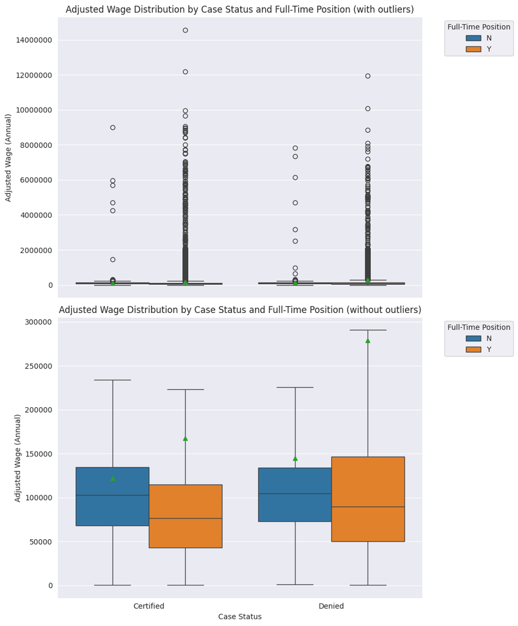

```python
# Create a figure with two subplots (2 rows, 1 column) for vertical arrangement
fig, axes = plt.subplots(2, 1, figsize=(10, 12), sharex=True) # sharex ensures x-axis scale is consistent, figsize adjusted for vertical

# Subplot 1 (top): Boxplot with outliers
sns.boxplot(data=test_data, x='case_status', y='adj_wage', hue='full_time_position', showmeans=True, ax=axes[0])
axes[0].set_title('Adjusted Wage Distribution by Case Status and Full-Time Position (with outliers)')
axes[0].set_xlabel('') # Remove x-label for top plot as it's shared and will be on the bottom plot
axes[0].set_ylabel('Adjusted Wage (Annual)')
axes[0].ticklabel_format(style='plain', axis='y') # Disable scientific notation for y-axis
axes[0].legend(title='Full-Time Position', bbox_to_anchor=(1.05, 1), loc='upper left')

# Subplot 2 (bottom): Boxplot without outliers
sns.boxplot(data=test_data, x='case_status', y='adj_wage', hue='full_time_position', showmeans=True, showfliers=False, ax=axes[1])
axes[1].set_title('Adjusted Wage Distribution by Case Status and Full-Time Position (without outliers)')
axes[1].set_xlabel('Case Status') # Keep x-label for the bottom plot
axes[1].set_ylabel('Adjusted Wage (Annual)') # Keep y-label as it's a new row
axes[1].ticklabel_format(style='plain', axis='y') # Disable scientific notation for y-axis
axes[1].legend(title='Full-Time Position', bbox_to_anchor=(1.05, 1), loc='upper left')

plt.tight_layout()
plt.show()
```

For approved visas, part time position adjusted wages had a higher median and greater range than did wages for full time positions. However, this may be due to the presence of some signficant outliers. The medians for both full time and part time jobs that were denied visas are roughly equivalent.

Click here to return to the Exploratory Data Analysis (EDA).